# Linear Models Procedure

#### **Content:**

##### Load necessary data set

For data description please check data/Description_USCRIME.txt

```r
library(here)
path = "../data/USCRIME.dat"
df_uscrime <- read.table(here(path), header=TRUE)

# we exclude the LF and NW
df_uscrime$LF <- NULL
df_uscrime$NW <- NULL

head(df_uscrime)
```

|  | R | Age | S | Ed | Ex0 | Ex1 | M | N | U1 | U2 | W | X |
| --- | --- | --- | --- | --- | --- | --- | --- | --- | --- | --- | --- | --- |
| 1 | 79.1 | 151 | 1 | 91 | 58 | 56 | 950 | 33 | 108 | 41 | 394 | 261 |
| 2 | 163.5 | 143 | 0 | 113 | 103 | 95 | 1012 | 13 | 96 | 36 | 557 | 194 |
| 3 | 57.8 | 142 | 1 | 89 | 45 | 44 | 969 | 18 | 94 | 33 | 318 | 250 |
| 4 | 196.9 | 136 | 0 | 121 | 149 | 141 | 994 | 157 | 102 | 39 | 673 | 167 |
| 5 | 123.4 | 141 | 0 | 121 | 109 | 101 | 985 | 18 | 91 | 20 | 578 | 174 |
| 6 | 68.2 | 121 | 0 | 110 | 118 | 115 | 964 | 25 | 84 | 29 | 689 | 126 |

#### DataFrame size

```
## [1] "num of row, num of col: 47, 12"
```

This number size is still manageable for R running od desktop PC.

### 1. Explorative Data Analysis (EDA)

We are interessted in finding relationships between the response **R** (Crime rate) and remaining responses.

```r
str(df_uscrime)
```

```
## 'data.frame':    47 obs. of  12 variables:
##  $ R  : num  79.1 163.5 57.8 196.9 123.4 ...
##  $ Age: int  151 143 142 136 141 121 127 131 157 140 ...
##  $ S  : int  1 0 1 0 0 0 1 1 1 0 ...
##  $ Ed : int  91 113 89 121 121 110 111 109 90 118 ...
##  $ Ex0: int  58 103 45 149 109 118 82 115 65 71 ...
##  $ Ex1: int  56 95 44 141 101 115 79 109 62 68 ...
##  $ M  : int  950 1012 969 994 985 964 982 969 955 1029 ...
##  $ N  : int  33 13 18 157 18 25 4 50 39 7 ...
##  $ U1 : int  108 96 94 102 91 84 97 79 81 100 ...
##  $ U2 : int  41 36 33 39 20 29 38 35 28 24 ...
##  $ W  : int  394 557 318 673 578 689 620 472 421 526 ...
##  $ X  : int  261 194 250 167 174 126 168 206 239 174 ...
```

```r
summary(df_uscrime)
```

```
##        R               Age              S                Ed
##  Min.   : 34.20   Min.   :119.0   Min.   :0.0000   Min.   : 87.0
##  1st Qu.: 65.85   1st Qu.:130.0   1st Qu.:0.0000   1st Qu.: 97.5
##  Median : 83.10   Median :136.0   Median :0.0000   Median :108.0
##  Mean   : 90.51   Mean   :138.6   Mean   :0.3404   Mean   :105.6
##  3rd Qu.:105.75   3rd Qu.:146.0   3rd Qu.:1.0000   3rd Qu.:114.5
##  Max.   :199.30   Max.   :177.0   Max.   :1.0000   Max.   :122.0
##       Ex0             Ex1               M                N
##  Min.   : 45.0   Min.   : 41.00   Min.   : 934.0   Min.   :  3.00
##  1st Qu.: 62.5   1st Qu.: 58.50   1st Qu.: 964.5   1st Qu.: 10.00
##  Median : 78.0   Median : 73.00   Median : 977.0   Median : 25.00
##  Mean   : 85.0   Mean   : 80.23   Mean   : 983.0   Mean   : 36.62
##  3rd Qu.:104.5   3rd Qu.: 97.00   3rd Qu.: 992.0   3rd Qu.: 41.50
##  Max.   :166.0   Max.   :157.00   Max.   :1071.0   Max.   :168.00
##        U1               U2              W               X
##  Min.   : 70.00   Min.   :20.00   Min.   :288.0   Min.   :126.0
##  1st Qu.: 80.50   1st Qu.:27.50   1st Qu.:459.5   1st Qu.:165.5
##  Median : 92.00   Median :34.00   Median :537.0   Median :176.0
##  Mean   : 95.47   Mean   :33.98   Mean   :525.4   Mean   :194.0
##  3rd Qu.:104.00   3rd Qu.:38.50   3rd Qu.:591.5   3rd Qu.:227.5
##  Max.   :142.00   Max.   :58.00   Max.   :689.0   Max.   :276.0
```

```r
library(ggplot2)
library(GGally)
```

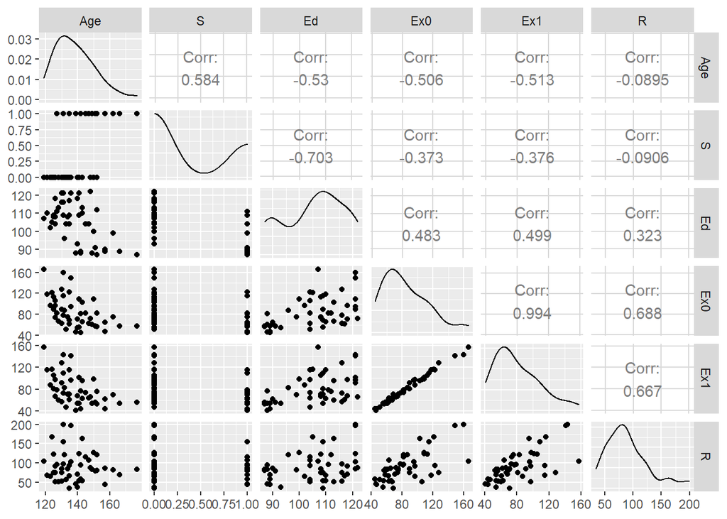

```r
m <- dim(df_uscrime)[2]
# Plot a pairs plot to find dependencies between covariates and the response R
index1 <- c(2:6, 1)
ggpairs(df_uscrime[,index1])
```

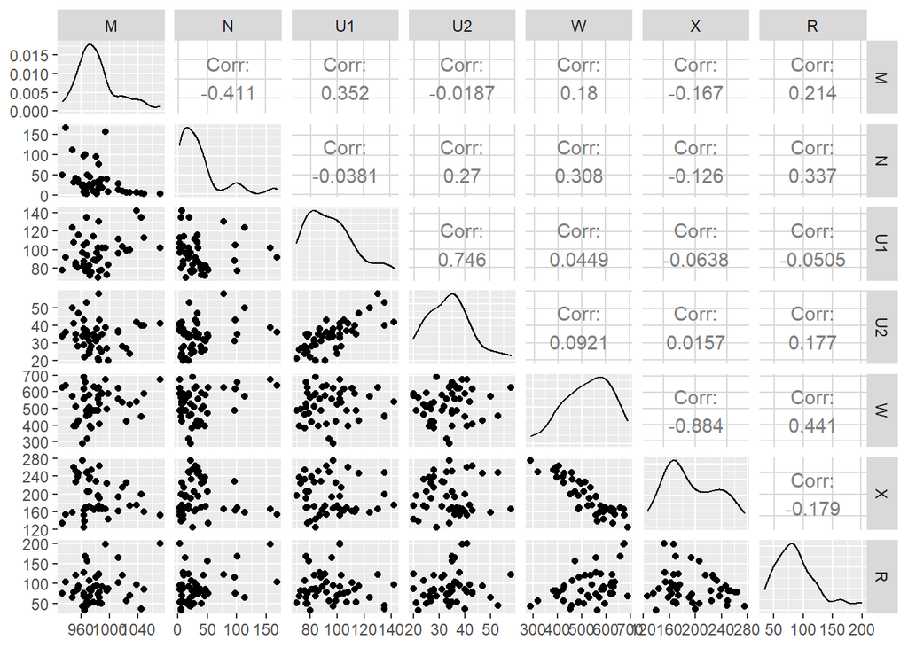

```r
index2 <- c(7:m, 1)
ggpairs(df_uscrime[,index2])
```

We can see a correlation between $(EX0,R)$; and $(EX1,R)$.

To recall: $EX$* represents the police expanditure in 1960 per capita and; $EX0$ represents the police expanditure in 1959 per capita

This correlation might be intuitive since the higher the crime rate the more the government invest to protect the citizens and to fight to decrease the crime rate but there is also a correlation in $(EX0, EX1)$, this might hint, that investing into police expanditures does not decrease the crime rate immediatelly, i.e. not immediatelly in the next year.

### 2. Covariates transformations if necessary

We transform all covariates with log and quadratic transformation. And look which trafos are the most suited.

```r
# log trafo
df_uscrime_log <- log(df_uscrime[, 2:ncol(df_uscrime)])
names(df_uscrime_log) <- sapply(names(df_uscrime_log), function(x) paste0(x, "_log"))
df_uscrime_log <- cbind(df_uscrime$R, df_uscrime_log)

# quadratic trafo
df_uscrime_sq <- (df_uscrime[, 2:ncol(df_uscrime)])^2
names(df_uscrime_sq) <- sapply(names(df_uscrime_sq), function(x) paste0(x, "_sq"))
df_uscrime_sq <- cbind(df_uscrime$R, df_uscrime_sq)
```

#### log transformation

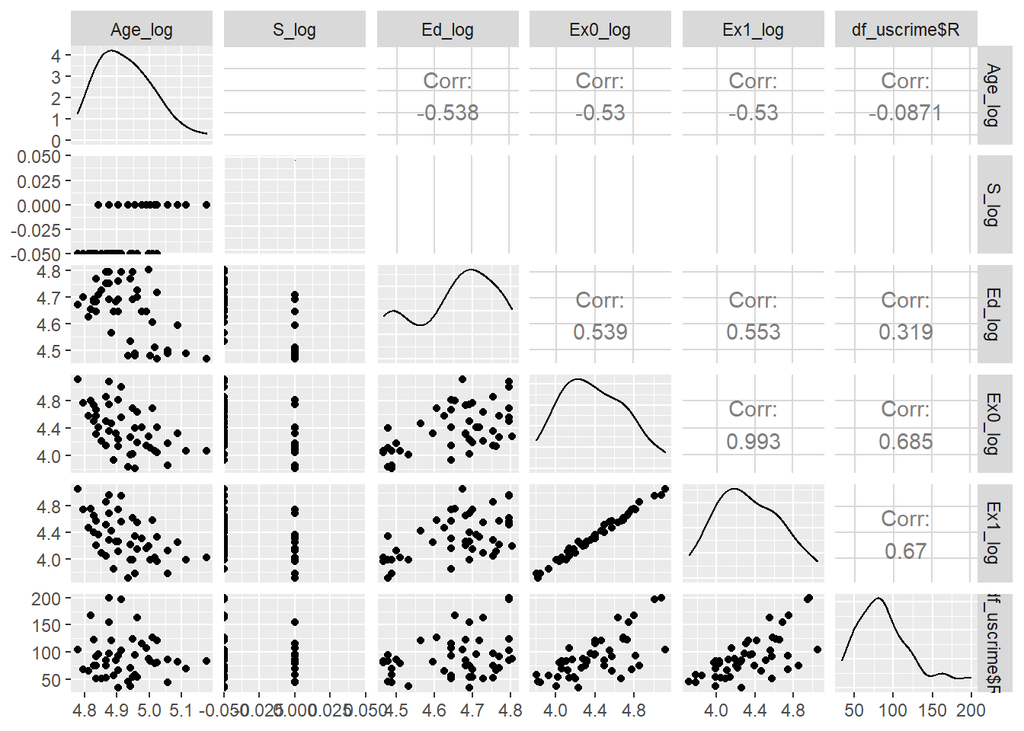

```r
ggpairs(df_uscrime_log[,index1])
```

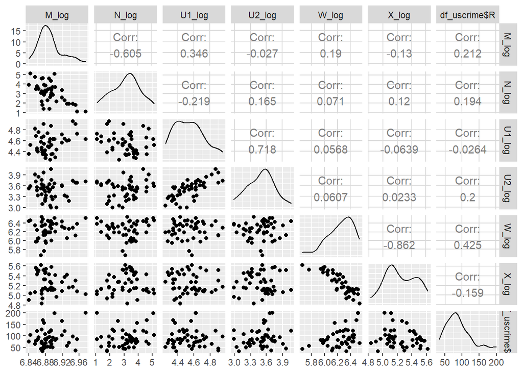

```r
ggpairs(df_uscrime_log[,index2])
```

#### squared tranformation

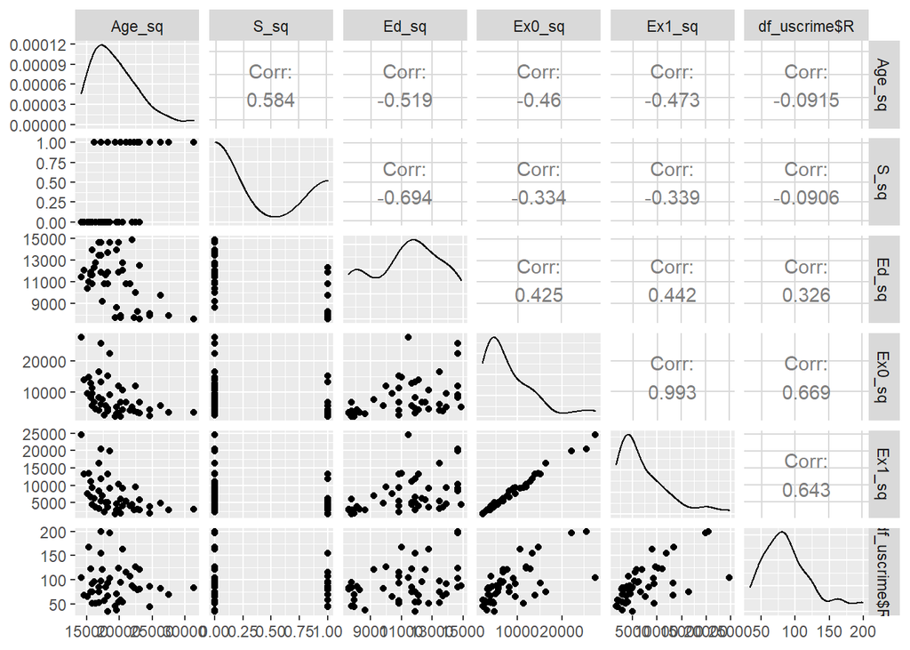

```r
ggpairs(df_uscrime_sq[,index1])
```

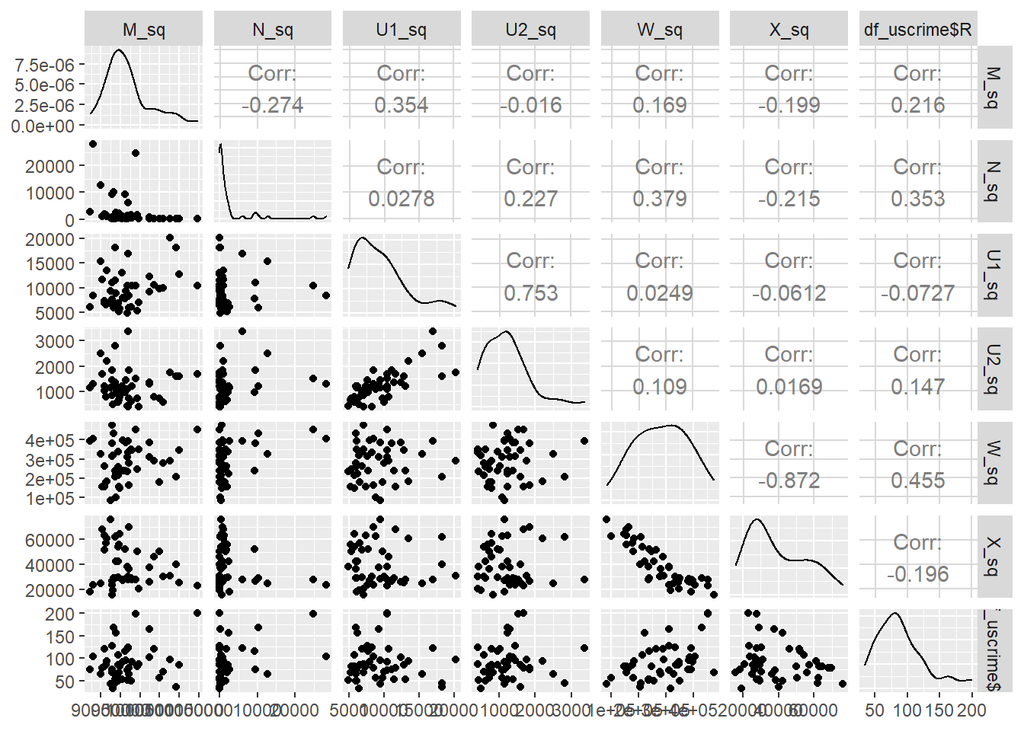

```r
ggpairs(df_uscrime_sq[,index2])
```

The plots do not hint any improvements, so we do not consider any transformation of covariates.\ However, more robust way would be to fit linear models with possible covariate transformations and\ and then compare R-Squared or to use AIC or BIC.

### 3. Fit a linear model

Now we fit the linear model

```r
linear_model <- lm(R ~., df_uscrime)

print(summary(linear_model))
```

```
##
## Call:
## lm(formula = R ~ ., data = df_uscrime)
##
## Residuals:
##    Min     1Q Median     3Q    Max
## -35.30 -12.48  -1.15  13.05  50.86
##
## Coefficients:
##               Estimate Std. Error t value Pr(>|t|)
## (Intercept) -683.94267  148.80924  -4.596  5.4e-05 ***
## Age            1.06058    0.38739   2.738  0.00966 **
## S             -6.17049   11.56670  -0.533  0.59708
## Ed             1.74411    0.59587   2.927  0.00598 **
## Ex0            1.55088    1.00817   1.538  0.13297
## Ex1           -0.58155    1.06816  -0.544  0.58959
## M              0.13488    0.17288   0.780  0.44051
## N             -0.04601    0.12440  -0.370  0.71372
## U1            -0.55055    0.38253  -1.439  0.15898
## U2             1.78151    0.83123   2.143  0.03912 *
## W              0.13283    0.10002   1.328  0.19276
## X              0.78095    0.22210   3.516  0.00123 **
## ---
## Signif. codes:  0 '***' 0.001 '**' 0.01 '*' 0.05 '.' 0.1 ' ' 1
##
## Residual standard error: 21.32 on 35 degrees of freedom
## Multiple R-squared:  0.7687, Adjusted R-squared:  0.696
## F-statistic: 10.58 on 11 and 35 DF,  p-value: 3.52e-08
```

So, significant are only the covariates: **Intercept, Age, Ed, U2, X**.

To compute the significance the so called *Wald test* or *t-test* was used, where the null hypothesis $H_0$ is that the corresponding coefficient is zero.

The residual standard error is the unbiased estimate of $\sigma$ and is roughly equal to 21.

```r
# linear_model$sigma
SSE <- sum(linear_model$residuals^2)
n <- nrow(df_uscrime)
p <- length(linear_model$coefficients)
sigma <- sqrt(SSE/(n-p))
print(sigma)
```

```
## [1] 21.32298
```

### 4. Select the best linear model by Akaike Information Criterion (AIC) and the step-wise procedure.

The Idea is to perform backward step-wise selection with AIC. Then, to perform the forward step-wise selection. Finally, compare both models from both procedure using F-Test or adjusted R-squared.

#### Backward Selection

```r
lm_full <- lm(R ~., df_uscrime)

lm_reduced <- step(lm_full, direction="backward", scale=0, trace=1)
```

```
## Start:  AIC=297.76
## R ~ Age + S + Ed + Ex0 + Ex1 + M + N + U1 + U2 + W + X
##
##        Df Sum of Sq   RSS    AIC
## - N     1      62.2 15976 295.95
## - S     1     129.4 16043 296.14
## - Ex1   1     134.8 16048 296.16
## - M     1     276.8 16190 296.57
## <none>              15913 297.76
## - W     1     801.9 16715 298.07
## - U1    1     941.8 16855 298.47
## - Ex0   1    1075.9 16989 298.84
## - U2    1    2088.5 18002 301.56
## - Age   1    3407.9 19321 304.88
## - Ed    1    3895.3 19809 306.06
## - X     1    5621.3 21535 309.98
##
## Step:  AIC=295.95
## R ~ Age + S + Ed + Ex0 + Ex1 + M + U1 + U2 + W + X
##
##        Df Sum of Sq   RSS    AIC
## - S     1     104.4 16080 294.25
## - Ex1   1     123.3 16099 294.31
## - M     1     533.8 16509 295.49
## <none>              15976 295.95
## - W     1     748.7 16724 296.10
## - U1    1     997.7 16973 296.80
## - Ex0   1    1021.3 16997 296.86
## - U2    1    2082.3 18058 299.71
## - Age   1    3425.9 19402 303.08
## - Ed    1    3887.6 19863 304.19
## - X     1    5896.9 21873 308.71
##
## Step:  AIC=294.25
## R ~ Age + Ed + Ex0 + Ex1 + M + U1 + U2 + W + X
##
##        Df Sum of Sq   RSS    AIC
## - Ex1   1     171.5 16252 292.75
## - M     1     563.4 16643 293.87
## <none>              16080 294.25
```

[output cut: 31 more lines]

```
## - Ed    1    6430.6 23373 305.83
## - X     1    8147.7 25090 309.16
## - Ex0   1   12019.6 28962 315.91
##
## Step:  AIC=291.83
## R ~ Age + Ed + Ex0 + U2 + W + X
##
##        Df Sum of Sq   RSS    AIC
## <none>              17351 291.83
## - W     1    1252.6 18604 293.11
## - U2    1    1628.7 18980 294.05
## - Age   1    4461.0 21812 300.58
## - Ed    1    6214.7 23566 304.22
## - X     1    8932.3 26283 309.35
## - Ex0   1   15596.5 32948 319.97
```

```r
summary(lm_reduced)
```

```
##
## Call:
## lm(formula = R ~ Age + Ed + Ex0 + U2 + W + X, data = df_uscrime)
##
## Residuals:
##     Min      1Q  Median      3Q     Max
## -38.306 -10.209  -1.313   9.919  54.544
##
## Coefficients:
##              Estimate Std. Error t value Pr(>|t|)
## (Intercept) -618.5028   108.2456  -5.714 1.19e-06 ***
## Age            1.1252     0.3509   3.207 0.002640 **
## Ed             1.8179     0.4803   3.785 0.000505 ***
## Ex0            1.0507     0.1752   5.996 4.78e-07 ***
## U2             0.8282     0.4274   1.938 0.059743 .
## W              0.1596     0.0939   1.699 0.097028 .
## X              0.8236     0.1815   4.538 5.10e-05 ***
## ---
## Signif. codes:  0 '***' 0.001 '**' 0.01 '*' 0.05 '.' 0.1 ' ' 1
##
## Residual standard error: 20.83 on 40 degrees of freedom
## Multiple R-squared:  0.7478, Adjusted R-squared:   0.71
## F-statistic: 19.77 on 6 and 40 DF,  p-value: 1.441e-10
```

We can see that the covariate $W$ does not have high enough significane. So, we will remove it.

```r
lm_reduced <- lm(R~Age+Ed+Ex0+U2+X, df_uscrime)
summary(lm_reduced)
```

```
##
## Call:
## lm(formula = R ~ Age + Ed + Ex0 + U2 + X, data = df_uscrime)
##
## Residuals:
##     Min      1Q  Median      3Q     Max
## -45.344  -9.859  -1.807  10.603  62.964
##
## Coefficients:
##              Estimate Std. Error t value Pr(>|t|)
## (Intercept) -524.3743    95.1156  -5.513 2.13e-06 ***
## Age            1.0198     0.3532   2.887 0.006175 **
## Ed             2.0308     0.4742   4.283 0.000109 ***
## Ex0            1.2331     0.1416   8.706 7.26e-11 ***
## U2             0.9136     0.4341   2.105 0.041496 *
## X              0.6349     0.1468   4.324 9.56e-05 ***
## ---
## Signif. codes:  0 '***' 0.001 '**' 0.01 '*' 0.05 '.' 0.1 ' ' 1
##
## Residual standard error: 21.3 on 41 degrees of freedom
## Multiple R-squared:  0.7296, Adjusted R-squared:  0.6967
## F-statistic: 22.13 on 5 and 41 DF,  p-value: 1.105e-10
```

#### Forward Selection

```r
null_model <- lm(R~1, df_uscrime)
selected_model <- step(null_model, direction="forward", scope~Age+S+Ed+Ex0+Ex1+M+N+U1+U2+W+X)
```

To spare some place the forward selection is omitted, insted the summary is showed below.

```r
summary(selected_model)
```

```
##
## Call:
## lm(formula = R ~ Ex0 + X + Ed + Age + U2 + W, data = df_uscrime)
##
## Residuals:
##     Min      1Q  Median      3Q     Max
## -38.306 -10.209  -1.313   9.919  54.544
##
## Coefficients:
##              Estimate Std. Error t value Pr(>|t|)
## (Intercept) -618.5028   108.2456  -5.714 1.19e-06 ***
## Ex0            1.0507     0.1752   5.996 4.78e-07 ***
## X              0.8236     0.1815   4.538 5.10e-05 ***
## Ed             1.8179     0.4803   3.785 0.000505 ***
## Age            1.1252     0.3509   3.207 0.002640 **
## U2             0.8282     0.4274   1.938 0.059743 .
## W              0.1596     0.0939   1.699 0.097028 .
## ---
## Signif. codes:  0 '***' 0.001 '**' 0.01 '*' 0.05 '.' 0.1 ' ' 1
##
## Residual standard error: 20.83 on 40 degrees of freedom
## Multiple R-squared:  0.7478, Adjusted R-squared:   0.71
## F-statistic: 19.77 on 6 and 40 DF,  p-value: 1.441e-10
```

#### Forward/Backward Selection

It is also possible to perform combined selection

```r
null_model <- lm(R~1, df_uscrime)
both <- step(null_model, direction="both", scope~Age+S+Ed+Ex0+Ex1+M+N+U1+U2+W+X)
```

```r
summary(both)
```

```
##
## Call:
## lm(formula = R ~ Ex0 + X + Ed + Age + U2 + W, data = df_uscrime)
##
## Residuals:
##     Min      1Q  Median      3Q     Max
## -38.306 -10.209  -1.313   9.919  54.544
##
## Coefficients:
##              Estimate Std. Error t value Pr(>|t|)
## (Intercept) -618.5028   108.2456  -5.714 1.19e-06 ***
## Ex0            1.0507     0.1752   5.996 4.78e-07 ***
## X              0.8236     0.1815   4.538 5.10e-05 ***
## Ed             1.8179     0.4803   3.785 0.000505 ***
## Age            1.1252     0.3509   3.207 0.002640 **
## U2             0.8282     0.4274   1.938 0.059743 .
## W              0.1596     0.0939   1.699 0.097028 .
## ---
## Signif. codes:  0 '***' 0.001 '**' 0.01 '*' 0.05 '.' 0.1 ' ' 1
##
## Residual standard error: 20.83 on 40 degrees of freedom
## Multiple R-squared:  0.7478, Adjusted R-squared:   0.71
## F-statistic: 19.77 on 6 and 40 DF,  p-value: 1.441e-10
```

### 5. Regression diagnostics

We use here R-base ploting tools. However, consider also the package: **ggplot2**.

Please consider the `linear_regression_appendinx.html` to check why for regression diagnostics the *residual analysis* is used.

#### Residuals analysis

##### Raw residuals against the covariates: Age and Education

The following types of plots we could use to find dependencies between covariates and the response.

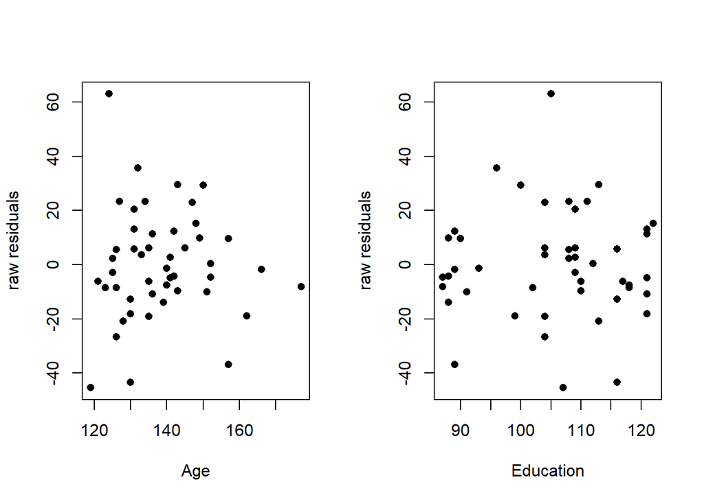

```r
par(mfrow=c(1,2))
plot(df_uscrime$Age, lm_reduced$residuals, ylab="raw residuals", xlab="Age",pch=16)
plot(df_uscrime$Ed, lm_reduced$residuals, ylab="raw residuals", xlab="Education",pch=16)
```

In both plots we can not see any dependency or systemic error. So, we could state that the covariates does not have any nonlinear influence on the response variable.

With the following plot we can check the overall model assumptions and also determine possible outliers.

```r
library(ggplot2)
```

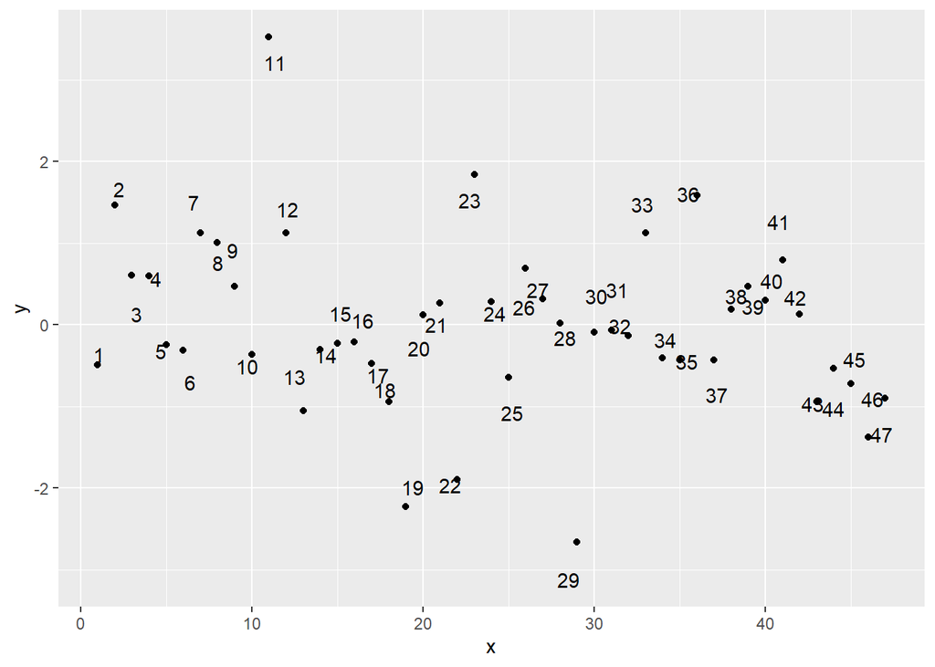

```r
student_res = rstudent(lm_reduced)

df_student <- data.frame(x = 1:nrow(df_uscrime), y = student_res)
ggplot(df_student, aes(x,y)) + geom_point() + geom_text(aes(label=1:nrow(df_uscrime)), position=position_jitter(width=0.5,height=0.5))
```

We can see that observation 11 might be an outlier, which perhaps needs further investigations. The overall plot looks good.

#### QQ Plot

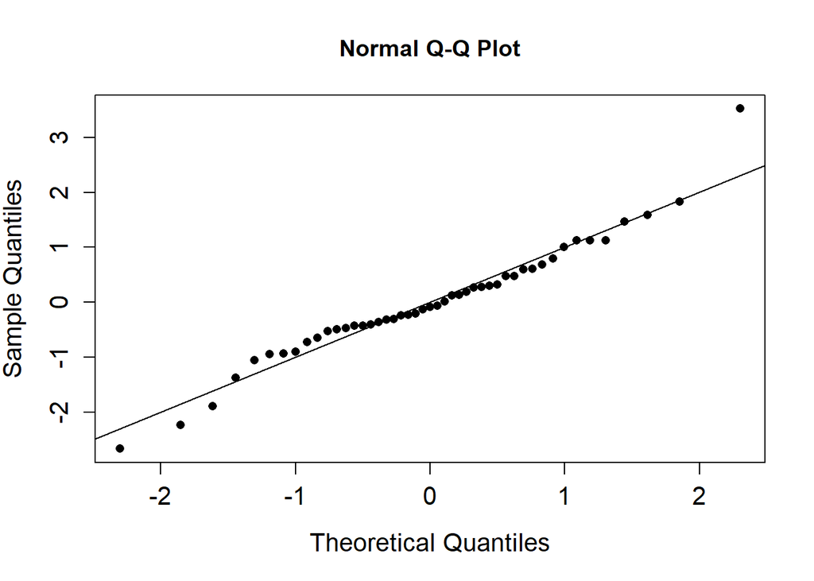

```r
qqnorm(student_res, pch=16, cex.lab=1.3, cex.axis=1.3)
abline(0,1)
```

As we can see the points lie along the idenity line which indicates that the normality assumption is satisfied.

#### Identyfing high leverage

If an observation indicates a high leverage, it means that the covariates values are outliers w.r.t. other covariate values.

```r
n <- nrow(df_uscrime)
p <- length(lm_reduced$coefficients)

# create the design matrix used to fit the lm_reduced model
X_red <- cbind(rep(1, n) ,df_uscrime$Age, df_uscrime$Ed, df_uscrime$Ex0, df_uscrime$U2, df_uscrime$X)

# compute the hat matrix
H <- X_red %*% solve(t(X_red) %*% X_red) %*% t(X_red)

# extract the diagonal and detect high leverages
h <- diag(H)
high_leverages <- which(h > 2*(p/n))
print(high_leverages)
```

```
## [1] 29
```